# Investigating the Error-Related Negativity During the Flanker Task

Author

Ariyana Das

Published

November 10, 2027

## Setup

```python
# Specify the required imports for your analysis
from pathlib import Path

from mini_mne import SimpleRaw, SimpleEpoch, grand_average, plot_evokeds

# Note how we can import a custom preprocessing function from a local script
from scripts.preproc import preprocess
```

```python
# Specify the required paths for your analysis
# Note that we now include a folder for saving preprocessed data
RAW_PATH = Path("data/raw")
PROCESSED_PATH = Path("data/processed")
```

## Introduction

Electroencephalography (EEG) is a non-invasive technique used to measure the brain’s electrical activity through electrodes placed on the scalp (Cohen, 2017). These electrodes detect changes in electrical voltage generated by the coordinated activity of large populations of neurons. EEG provides continuous recordings of brain activity with high temporal resolution, allowing researchers to examine neural processes occurring within milliseconds. This makes it particularly useful for investigating the timing of cognitive processes, including attention, decision-making, and error monitoring (Kappenman et al., 2021) Event-related potentials (ERPs) are obtained by averaging EEG recordings time-locked to specific events, such as a stimulus or a behavioural response. This process allows researchers to identify patterns of neural activity associated with cognitive processes. One component associated with error monitoring is the error-related negativity (ERN), a negative-going waveform that occurs shortly after an incorrect response. The ERN typically emerges within approximately zero to one hundred milliseconds following an error and is more prominent over frontocentral electrode sites, particularly FCz (Dehaene, 2018). It is an important measure for investigating how the brain detects errors and supports behavioural adjustment (Lenzoni et al., 2022)

### Literature Review

The Erickson flanker task is commonly used to investigate response monitoring and elicit the ERN. Participants are instructed to respond to a central target while ignoring surrounding distractor stimuli. These flankers can be congruent or incongruent with the target, with incongruent trials creating competition between possible responses; researchers can examine the neural processes associated with error detection (Kappenman et al., 2021) Although the ERN is associated with error processing, its underlying function remains theoretically debated. The conflict monitoring account proposes that the ERN reflects the detection of competing response tendencies, signalling the need for increased cognitive control (Botwinick et al., 2001). In contrast, the reinforcement learning account suggests that the ERN reflects a dopamine-related signal generated when an outcome is worse than expected, supporting behavioural adaptation (Holroyd & Coles, 2002). More recent research continues to examine the neural mechanisms underlying error monitoring, highlighting the complexity of the processes involved (Fue at al., 2023). Beyond theoretical explanations, research has demonstrated that neural error monitoring is relevant to broader cognitive and clinical processes. For example, ERN activity has been investigated as a potential marker of altered performance monitoring across psychiatric conditions, with differences in response patterns reported between clinical populations (Harpfer & Riesel, 2026). Research has also examined how emotional states influence error processing, suggesting that the brain’s response to mistakes is not determined by accuracy alone (Nunez-Estupinan et., 2022). Furthermore, evidence indicates that relationships between ERN activity and subsequent behavioural adjustments are more complex than previously assumed. (LoTemplio et al., 2023)

### Present analysis

The present analysis examines the ERN using the Flanker task data set from the ERP core resource (Kappenman et al., 2021). Response-locked EEG activity following correct and incorrect responses is compared at the FCz electrode, focusing on the zero to the one hundred millisecond interval after the response. This analysis aims to determine whether the expected ERN pattern is observable in the grand average waveforms.

## Methods

### Participants

The dataset was obtained from the ERP CORE (Compendium of Open Resources and Experiments) resource developed by Kappenman et al. (2021), distributed under the Creative Commons Attribution-Share Alike 4.0 International (CC BY-SA 4.0) licence. The original study included 40 healthy adult participants recruited from the University of California, Davis. The sample consisted of 25 females and 15 males, with a mean age of 21.5 years (SD = 2.87; range = 18–30 years). Thirty-eight participants were right-handed. Inclusion criteria required participants to have native English proficiency, normal colour perception, normal or corrected-to-normal vision, and no self-reported history of neurological injury or disease. Kappenman et al. reported an ERN analysis sample of 36 participants after excluding participants with excessive artefacts.

### Procedure

The ERN was elicited using a modified Eriksen Flanker task. Participants viewed a central arrowhead pointing either left or right, surrounded by four flanking arrowheads. On congruent trials, the flankers pointed in the same direction as the central target, whereas on incongruent trials, they pointed in the opposite direction. Participants were instructed to identify the direction of the central arrowhead by pressing the corresponding left- or right-hand response button while ignoring the surrounding flankers. The task generated correct and incorrect responses, allowing researchers to examine neural activity associated with error monitoring. The present analysis focused on comparing EEG activity following these two response types (Kappenman et al., 2021).

### EEG recording

EEG recordings were originally collected using a BioSemi ActiveTwo recording system with active electrodes. Thirty scalp electrodes were mounted in an elastic cap according to the international 10–20 system. The recorded electrode positions were FP1, F3, F7, FC3, C3, C5, P3, P7, P9, PO7, PO3, O1, Oz, Pz, CPz, FP2, Fz, F4, F8, FC4, FCz, Cz, C4, C6, P4, P8, P10, PO8, PO4 and O2 (Kappenman et al., 2021).. The common mode sense (CMS) electrode was positioned at PO1, while the driven right leg (DRL) electrode was positioned at PO2. Horizontal electrooculogram (HEOG) activity was recorded using electrodes positioned lateral to the external canthus of each eye, while vertical electrooculogram (VEOG) activity was recorded using an electrode below the right eye. Signals were low-pass filtered using a fifth-order sinc filter with a half-power cutoff of 204.8 Hz before being digitised at 1024 Hz with 24-bit resolution (Kappenman et al., 2021).

### Analysis parameters

The present analysis investigated the error-related negativity by comparing response-locked EEG activity following correct and incorrect responses. The parameters were selected using the ERN recommendations in Table 1 of Kappenman et al. (2021). The FCz electrode was selected as the representative measurement site, as this is the recommended frontocentral location for examining the ERN. The analysis was time-locked to the participant’s response rather than stimulus presentation. Epochs extended from −600 to +400 ms relative to the response, with baseline correction applied between −400 and −200 ms. The two conditions selected for comparison were response/correct and response/incorrect. A 0.1–30 Hz band-pass filter was used for the present analysis, following the filtering settings specified for the practical pipeline.

#### Preprocessing parameters

The pipeline re-referenced the EEG data and applied a band-pass filter between 0.1 and 30 Hz to retain relevant EEG activity while reducing unwanted low- and high-frequency signals. Processed recordings were subsequently saved as separate files in the data/processed directory for use in the subsequent analysis.

```python
FILTER_SETTINGS = {
    "low_cutoff": 0.1,
    "high_cutoff": 30.0
}

# This setting re-references to averaged mastoids (P9/P10 as proxy)
# To use an average reference, replace ["P9", "P10"] with None
REFERENCE = ["P9","P10"]
```

#### Epoching parameters

The epoch window was set from −0.6 to +0.4 seconds relative to the response, corresponding to 600 ms before and 400 ms after the response. Baseline correction was applied using the interval from −0.4 to −0.2 seconds. Epochs were separated according to response accuracy into correct and incorrect response conditions, allowing the ERN to be examined between the two conditions.

```python
TMIN = -0.6 # epoch start relative to critical event
TMAX = 0.4  # epoch end relative to critical event

BASELINE = (-0.4,-0.2) # baseline interval

# critical conditions for averaging and epoching
CONDITIONS = ["response/correct", "response/incorrect"]

REJECT = {
    "eeg": 150e-6,
    "eog": 250e-6
}
```

## Data analysis

### Preprocessing

The preprocessing stage was performed on the 40 raw EEG recordings using the custom Python preprocessing function imported from scripts.preproc.py. Each recording was loaded individually using the Simple Raw function. The preprocessing function was then applied using the previously defined reference and filter settings. The processed recordings were saved individually in the data/processed directory, allowing them to be accessed during the epoching and averaging steps.

```python
for raw_file in RAW_PATH.glob("ERN/*_raw.fif.gz"):

    # extract subject number
    subj_ID = raw_file.stem.split("_")[0]

    # read in raw file
    raw = SimpleRaw(raw_file)

    # preprocess raw file
    # note how we draw on a custom preprocessing function here
    processed = preprocess(raw,
                            reref_params = REFERENCE,
                            filter_low_cutoff = FILTER_SETTINGS["low_cutoff"],
                            filter_high_cutoff = FILTER_SETTINGS["high_cutoff"])

    processed.save(PROCESSED_PATH / f"{subj_ID}_raw.fif.gz", overwrite = True)
```

### Epoching and averaging

Following preprocessing, the continuous EEG recordings were segmented into response-locked epochs for correct and incorrect responses. Epochs extended from −0.6 seconds (TMIN) to +0.4 seconds (TMAX) relative to the response. Baseline correction was applied from −0.4 to −0.2 seconds before the response. Epochs exceeding the rejection thresholds of 150 µV for EEG and 250 µV for EOG were excluded. The remaining epochs were averaged separately for correct and incorrect responses for each participant, producing individual ERP waveforms. These participant-level averages were then stored for the grand-average analysis.

```python
# initialise empty dictionary to hold single-subject averages
ss_avs = {}

for cond in CONDITIONS:
    ss_avs[cond] = []

# loop through all processed participants
for processed_file in PROCESSED_PATH.glob("*_raw.fif.gz"):

    # read in preprocessed file
    processed = SimpleRaw(processed_file)

    # extract events
    events, event_id = processed.get_events()

    # create epochs
    epochs = SimpleEpoch(
        processed,
        events,
        event_id,
        tmin=TMIN,
        tmax=TMAX,
        baseline=BASELINE,
        reject=REJECT
    )

    # subset epochs and average by condition
    for cond in CONDITIONS:
        if len(epochs[cond]) > 0:
            av = epochs[cond].average()
            ss_avs[cond].append(av)
        else:
            print(f"Skipping {cond} for {processed_file.name}: no usable epochs")
```

### Grand average

Individual ERP averages were calculated separately for correct and incorrect responses across the participant recordings. The analysis code iterated through the processed recordings, extracted the relevant epochs and calculated an average for each response condition. Individual participant averages were then combined across participants to generate a grand-average waveform for each condition. The resulting grand averages included 40 participant averages for correct responses and 37 for incorrect responses. These waveforms were plotted at FCz to visually compare neural activity following correct and incorrect responses.

```python
# create an empty dict to hold our grand averages
grand_avs = {}

for cond in CONDITIONS:
    grand = grand_average(ss_avs[cond])
    grand_avs[cond] = grand
```

## Results

The grand average waveforms for correct and incorrect responses are presented at electrode FCz. The analysis included 40 participant averages for correct responses and 37 participant averages for incorrect responses. The waveforms were examined within the 0–100 ms interval following the response, corresponding to the expected time window of the error-related negativity (ERN). The grand average demonstrated a difference in EEG activity between correct and incorrect responses. In particular, incorrect responses produced a more pronounced negative-going deflection shortly after response onset compared with correct responses. This pattern was most evident within the selected ERN analysis window. The observed difference is consistent with the expected frontocentral response associated with error processing.

### Grand average: expected effect

The grand averages were compared at the FCz electrode to examine the expected Error-Related Negativity (ERN). The analysis focused on the 0–100 ms period following the response, where incorrect responses were expected to produce a more pronounced negative-going waveform than correct responses.

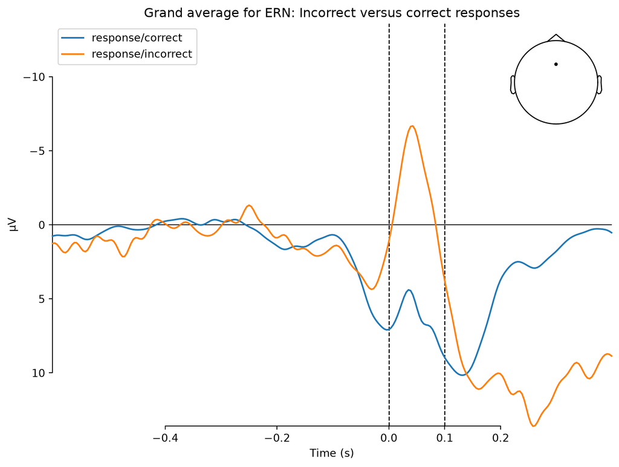

```python
selected_electrode = "FCz"
plot_title = "Grand average for ERN: Incorrect versus correct responses"
analysis_window_start = 0.0
analysis_window_end = 0.1

plot_evokeds(grand_avs, picks = selected_electrode, invert_y = True, title = plot_title, vlines = [analysis_window_start, analysis_window_end])
```

## Discussion and reflection

This analysis investigated the error-related negativity (ERN) by comparing EEG activity following correct and incorrect responses during the Flanker task. The grand average waveforms demonstrated a more pronounced negative-going response following incorrect responses than correct responses at electrode FCz. This pattern was consistent with the expected characteristics of the ERN, which is typically observed as a negative-going response shortly after an incorrect response and is strongest over frontocentral electrode sites (Kappenman et al., 2021).

Overall, the findings broadly replicated the expected ERN response described by Kappenman et al. (2021). However, the present analysis was limited to a visual comparison of the grand average waveforms at a single electrode. No inferential statistical testing was conducted, meaning that the observed difference cannot be interpreted as statistically significant. Additionally, differences in the number of usable participant averages between the correct and incorrect conditions may have influenced the comparison.

Completing this analysis provided practical experience in applying an EEG processing pipeline to an existing dataset. It demonstrated how continuous EEG recordings can be pre-processed, segmented into response-locked epochs and averaged across participants to identify an ERP component. this process highlighted the value of reproducible analytical workflows, as each stage contributed to producing and interpreting the final grand average.

## References

Botvinick, M. M., Braver, T. S., Barch, D. M., Carter, C. S., & Cohen, J. D. (2001). Conflict monitoring and cognitive control. *Psychological Review, 108*(3), 624–652. https://doi.org/10.1037/0033-295X.108.3.624

Cohen, M. X. (2017). Where does EEG come from and what does it mean? *Trends in Neurosciences, 40*(4), 208–218. https://doi.org/10.1016/j.tins.2017.02.004

Dehaene, S. (2018). The error-related negativity, self-monitoring, and consciousness. *Perspectives on Psychological Science, 13*(2), 161–165. https://doi.org/10.1177/1745691618754502

Fu, Z., Sajad, A., Errington, S. P., Schall, J. D., & Rutishauser, U. (2023). Neurophysiological mechanisms of error monitoring in human and non-human primates. *Nature Reviews Neuroscience, 24*, 153–172. https://doi.org/10.1038/s41583-022-00670-w

Härpfer, K., & Riesel, A. (2026). On the role of neural error monitoring in clinical research: An integrative model of altered error-related brain activity and psychopathology. *Clinical Psychology Review, 123*, 102673. https://doi.org/10.1016/j.cpr.2025.102673

Holroyd, C. B., & Coles, M. G. H. (2002). The neural basis of human error processing: Reinforcement learning, dopamine, and the error-related negativity. *Psychological Review, 109*(4), 679–709. https://doi.org/10.1037/0033-295X.109.4.679

Kappenman, E. S., Farrens, J. L., Zhang, W., Stewart, A. X., & Luck, S. J. (2021). ERP CORE: An open resource for human event-related potential research. *NeuroImage, 225*, 117465. https://doi.org/10.1016/j.neuroimage.2020.117465

Lenzoni, S., Baker, J., Sumich, A. L., & Mograbi, D. C. (2022). New insights into neural networks of error monitoring and clinical implications: A systematic review of ERP studies in neurological diseases. *Reviews in the Neurosciences, 33*(2), 161–179. https://doi.org/10.1515/revneuro-2021-0054

LoTemplio, S. B., Lopes, C. L., McDonnell, A. S., Scott, E. E., Payne, B. R., & Strayer, D. L. (2023). Updating the relationship of the Ne/ERN to task-related behavior: A brief review and suggestions for future research. *Frontiers in Human Neuroscience, 17*, 1150244. https://doi.org/10.3389/fnhum.2023.1150244

Nuñez-Estupiñan, X., Berticelli, L. Z., de Almeida, R. M. M., & Gauer, G. (2022). Aversiveness of errors and the error-related negativity (ERN): A systematic review on the affective states’ manipulations findings. *Cognitive, Affective, & Behavioral Neuroscience, 22*, 754–776. https://doi.org/10.3758/s13415-022-01002-2

### Generative AI Declaration

Generative artificial intelligence, specifically CLAUDE, ChatGPT and Grammarly, was used to troubleshoot aspects of the Python code on Positron and the Quarto analysis workflow on the GitHub site. AI assistance was used to correct grammar, rephrase sentence formation where required, and edit written sections of the report. The analysis was run and reviewed by myself, the author, who was responsible for checking the accuracy of the information, interpreting results and ensuring the final submission reflected my understanding of this topic. Finally, ChatGPT was used to edit the reference list before submission. All scientific analyses were completed by the submitting author.